# Residual Votes and Ballot Design, 2000–2024

A punch card from Palm Beach County, and the one subtraction no agency performs

Democracy’s Data

Last updated September 13, 2026 at 10:53a EDT

A ballot is just paper, and paper is not supposed to decide elections. Does the design of a ballot actually change election outcomes? Palm Beach County, Florida, put that question beyond argument on 7 November 2000. Its presidential ballot ran the tickets down two facing pages with one column of punch holes between them. On the left-hand page, Bush was first and Gore second. In the column of holes down the middle, the second hole belonged to Pat Buchanan.

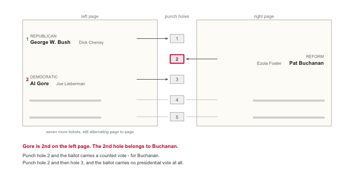

**Figure 1. The Palm Beach County presidential ballot, November 2000.** A sketch, not a facsimile: only the arrangement the U.S. Commission on Civil Rights recorded is drawn. The tickets sit on two facing pages with the punch holes down the centre, Bush and Gore first and second on the left page, and the Reform Party hole second in the column. A voter who counted names down the left page and punched the matching hole voted for a candidate they had not read.

That sheet of paper produced two failures, and only one leaves a trace. A voter who took Gore’s position in the list and punched the second hole cast a counted vote, for Buchanan, and no arithmetic will ever find it. A voter who caught the mistake and punched Gore as well spoiled the ballot — an **overvote**, two marks in a race that allows one, which no counting machine can read as a choice. By the Commission’s count, roughly 19,000 Palm Beach ballots carried more than one presidential punch.[^1] Those ballots were counted as ballots and contain no president. The presidency turned on 537 votes in Florida that year.[^2]

The second failure is a thing you can count. Take the ballots cast, subtract the votes counted in the top race, and what is left over is the **residual vote**: ballots that entered the system without a usable choice for president, whether left blank (an **undervote**), marked twice (an overvote), or spoiled in some other way the machine could not read. After 2000, Ansolabehere and Stewart computed exactly that for every county they could and showed that residual rates varied with the **voting equipment** in use — punch cards, lever machines, hand-counted paper, paper ballots read by an optical scanner, electronic touch screens — in a patterned way.[^3] Punch cards were worst; hand-counted paper and optical scan far better. That evidence, and the report of the Caltech/MIT Voting Technology Project that grew out of the same recount,[^4] helped drive the Help America Vote Act of 2002 — the federal law that paid states to replace their old machines — and the end of punch-card voting.[^5]

Design moves votes measurably, and the residual-vote rate is how you see it. So this brief computes that rate for the whole country in 2024 — and finds that the harder problem is now the record itself.

## The test

The measure needs two numbers per place: ballots cast and presidential votes counted. No agency publishes both, which is why nobody publishes the residual vote. The ballots come from the *Election Administration and Voting Survey*, the questionnaire the U.S. Election Assistance Commission sends to every election office in the country after each federal election, asking each office to report on the election it just ran; the 2024 answers, Version 2, are downloadable from the [Commission](https://www.eac.gov/research-and-data/datasets-codebooks-and-surveys), and item F1a is the box marked *total ballots cast*. The votes come from the fifty-one state **canvasses** — the official count each state certifies after election day — gathered county by county into one public file by [Tony McGovern](https://github.com/tonmcg/US_County_Level_Election_Results_08-24), which this book’s data-sources chapter describes.

| We need | Who has it | What it is |
| --- | --- | --- |
| Ballots cast | Election Assistance Commission (EAVS), item F1a | An administrative survey of every election office |
| Presidential votes counted | State canvasses, compiled into county returns | The official count, by county |

Why these sources, when the question is about individual ballots? The record that answers it properly is the cast vote record, which shows what each ballot actually carried — and it exists for a few dozen jurisdictions, which is not a country. Certified returns cover everywhere but are totals by construction, silent about any single ballot; the returns chapter sets out that limit. The subtraction is the one measure that works everywhere, and it buys that reach by giving up the reason a ballot came up empty.

The subtraction also has a property most measures lack. You cannot count more presidential votes than there were ballots to carry them, so the residual vote has a hard floor at zero. A negative residual vote is not a low rate; it is proof that one of the two sources is wrong. That turns the measure into a test of the record as well as a measurement of the ballots.

## The data

The survey is one table, one row per election jurisdiction — the office that runs an election, 6,461 of them. Jurisdictions are counties in most states, but Wisconsin, Michigan and most of New England run elections by township. Those township rows are summed into counties using the first five digits of the **FIPS code**, the number the federal government assigns every place, whose first two digits name the state and first five the county. The returns come one row per county. The two are joined on the FIPS code, carried as text throughout, because 268 of the 2,890 county codes begin with a zero that a numeric column would silently drop. One joined row looks like this:

| State | County | FIPS | Ballots cast (EAVS) | Presidential votes | Residual | Residual rate (%) |
| --- | --- | --- | --- | --- | --- | --- |
| Pennsylvania | Allegheny County | 42003 | 722248 | 720504 | 1744 | 0.241 |

Allegheny County took in 722,248 ballots and counted 720,504 presidential votes. Subtract the second from the first and 1,744 ballots are left over that recorded no president: that is the residual vote. Divide it by the ballots cast — 1,744 out of 722,248 — and the **residual-vote rate** is 0.24% of everything cast. Every county in the file gets the same two steps.

Two cleaning decisions matter enough to state. First, the survey writes “did not answer” and “does not apply” as negative codes in the same columns as the counts. Every negative value is therefore set to missing before anything is added up; summed as they stand, those codes subtract real ballots from real counties. Second, where the join produced an impossible answer, more presidential votes than ballots, the row was not dropped. A disagreement between two official sources is a finding, and tidying it away would destroy it.

The result is four tables. `counties.csv` holds one row per county: `fips`, `ballots` (item F1a, summed to the county), `total_votes` (the presidential total), `residual` (the subtraction), `residual_rate` (the same thing as a percentage of ballots), and `state_usable`. That last column is a judgment this brief attaches, not a fact from either source: it flags three whole states whose answers imply they read “ballots cast” to mean something else. `anomalies.csv` holds the 103 impossible rows, with the same columns. `unusable_states.csv` names the three set-aside states and gives each a `reason`. `states.csv` rolls the usable counties up to state level.

> **Before you read on, commit to a number.** Two official sources describe the same 2,993 counties, and the subtraction between them cannot come out below zero unless one of them is wrong. **In how many counties does it?** Write down a count out of 2,993 before you look.

## What it says about democracy

| Statistic | Value |
| --- | --- |
| Counties with a usable comparison | 2,803 |
| Median county residual rate (%) | 0.93 |
| 25th percentile (%) | 0.64 |
| 75th percentile (%) | 1.39 |
| Aggregate across all usable counties (%) | 1.39 |

The **median** county — the one in the middle when every county is ranked by its rate, with as many above it as below — has a residual vote rate of 0.93%: about one ballot in a hundred arriving without a usable presidential vote. The middle half of counties, setting aside the quarter with the lowest rates and the quarter with the highest, sit between 0.64% and 1.39%. One percent sounds small. In a state decided by twenty thousand votes it is not. And it is the size of number that design moves: one bad butterfly pushed one county’s spoiled ballots into the tens of thousands.

Most readers write down zero for the prompt above; an official count is not the sort of thing one expects to come out impossible. **103 counties report more presidential votes than ballots cast.** Figure 2 puts them on the same axis as everybody else.

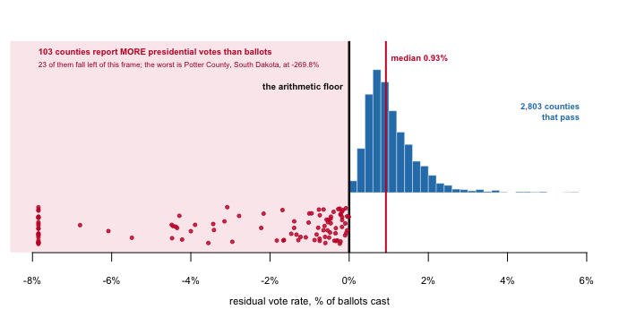

**Figure 2. The arithmetic floor, and 103 counties on the wrong side of it.** A histogram — bars counting how many counties fall in each narrow band of rate — with the floor drawn in, because this measure’s defining property is a boundary: nothing can sit left of the heavy black line and still be a measurement. The blue bars are the 2,803 counties whose two sources are at least consistent, with the median marked in red at 0.93%. Each red dot is a county reporting more presidential votes than ballots, spread vertically so overlapping cases stay countable. 23 fall left of the frame entirely, the worst at -269.8% in Potter County, South Dakota.

| State | County | Ballots (EAVS) | Presidential votes | Excess votes |
| --- | --- | --- | --- | --- |
| Illinois | Cook County | 1,112,978 | 2,056,800 | 943,822 |
| Missouri | Jackson County | 196,230 | 317,702 | 121,472 |
| Illinois | Winnebago County | 70,393 | 121,048 | 50,655 |
| Illinois | McLean County | 51,973 | 86,168 | 34,195 |
| Illinois | Knox County | 10,741 | 22,175 | 11,434 |
| Vermont | Chittenden County | 86,068 | 96,405 | 10,337 |

The largest gap is Cook County, Illinois, and it is diagnosable. The survey row for Cook County reports 1,112,978 ballots cast; the returns give the county 2,056,800 presidential votes, which is 943,822 more votes than there were ballots to carry them. The reason is that the City of Chicago runs its own elections, through a board separate from the Cook County Clerk, who runs them for the suburbs.[^6] The survey therefore has two rows where the returns have one: its county row is the suburbs alone, while the canvass counts the whole county, city included. The summing of smaller units into counties assumed that every smaller unit sits inside a county code, and here one does not, in the second most populous county in America. Which source is wrong cannot be determined from here; that one of them is wrong can be, and that is more than either source discloses about itself.

3,143 counties, from Census TIGER 2020 boundaries. Hover any county. County outlines are simplified to about ten vertices each; nothing in the argument rests on the shape of a county line.

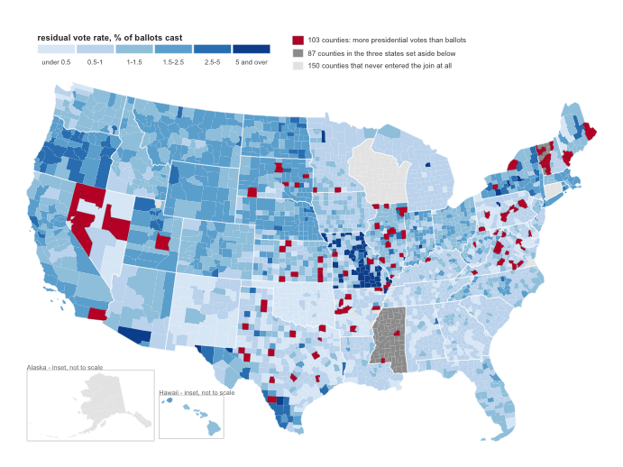

The exceptions have their own stories, and each was found by the arithmetic failing rather than by any documentation.

| State | Median rate (%) | Why it was set aside |
| --- | --- | --- |
| District of Columbia | 87.70 | median rate implausible |
| Mississippi | 0.00 | every county exactly 0 |
| Vermont | 5.83 | median rate implausible |

The floor also catches errors in one direction only. Wabash County, Illinois survives the test at 62.7%, nearly two thirds of its ballots recording no president, which no plausible mechanism produces. An error that inflates the rate passes the test and looks like data.

What survives is still most of the country: 2,803 of the 2,993 counties joined, or 94%. On those, about one ballot in a hundred is cast and records no president. And the audit is the other half of the finding. Two official datasets describing the same election disagree in 103 counties and three whole states, and nobody reconciles them, because no agency owns the comparison. The number that detected the Palm Beach ballot’s kind of failure still has to be assembled, by hand, from two files that were never built to meet.

## What this brief cannot tell you

**It cannot say why any ballot is blank.** A deliberate abstention, a spoiled mark and a scanner failure all count the same in the subtraction. That is why the classic studies compare equipment types across otherwise similar places rather than reading levels directly: the level in one county alone attributes nothing. No equipment data is joined here, so the comparison that made this measure famous is not run in these pages.

**It cannot say which source is wrong** in any of the 103 impossible counties — only that one of them is. Settling it would take the underlying certified canvasses, county by county.

**It cannot catch errors on the survivable side of zero.** Wabash County is almost certainly as broken as the red counties, and it passes. A floor is a one-way test.

**And it is one election.** A single year is a photograph. Whether rates still vary by equipment as they did in 2000 needs more years and the equipment join, and both are extensions below.

## What you should have learned

- A residual vote is ballots cast minus votes counted in the top race — a countable trace of ballot failure. In 2024 the median county’s rate was 0.93% of ballots cast.
- Ballot design moves that number measurably: after the 2000 election, residual rates sorted by equipment type, punch cards worst, and the finding helped end punch-card voting by law.
- The measure has a floor at zero, and 103 of 2,993 counties fall below it — proof that one of two official sources is wrong in each, though not which.
- Three whole states, one of them reporting exactly 0.000% everywhere, answered the ballots-cast question with something else and had to be set aside.
- No agency publishes both halves of the subtraction, so the number capable of detecting the next bad ballot design is published by nobody.

## Extensions

None of these is answered above, and every one can be answered from the tables the Sources section hands over.

- `counties.csv` has `residual_rate` for every county, with `state_usable` beside it. Sort the usable counties by rate. Which places lose the most votes between the ballot and the count, and do they share anything?
- `anomalies.csv` holds the impossible rows. Sort by `residual` and read the worst ten. How many look like Cook County — a city counted separately from its county?
- `unusable_states.csv` gives each excluded state a `reason`. Decide whether you agree with each exclusion, and what including the state would do to the national median.
- `states.csv` has a `residual_rate` per state. Compare the highest and lowest usable states. Is a high state rate more plausibly voters, ballot design, or reporting?

Two stretch ideas point past the spreadsheet. The survey this brief takes its ballots from also asks what voting equipment each jurisdiction uses. Download the release from the Commission’s address below, join the equipment items onto `counties.csv`, and rerun the 2000-era comparison on 2024 data. And for one jurisdiction that publishes cast vote records, count its blank and overvoted presidential ballots directly and check the subtraction’s answer against the ballots’ own.

## Sources

**Data**

- U.S. Election Assistance Commission, *Election Administration and Voting Survey 2024*, Version 2, item F1a. Version 2 rather than Version 1: the first release was corrected, and the Commission’s errata note says what changed. https://www.eac.gov/sites/default/files/2026-02/2024_EAVS_for_Public_Release_nolabel_V2_csv.zip
- County-level presidential returns for 2024, from Tony McGovern, *United States General Election Presidential Results by District, Ward, or County from 2008 to 2024*, by way of `pres2024_counties.csv` in the data-sources chapter, which documents the download and what the file is and is not. https://github.com/tonmcg/US_County_Level_Election_Results_08-24
- U.S. Census Bureau, TIGER/Line 2020 county and state boundaries, for the map. https://www2.census.gov/geo/tiger/TIGER2020/COUNTY/tl_2020_us_county.zip and https://www2.census.gov/geo/tiger/TIGER2020/STATE/tl_2020_us_state.zip

**Academic literature**

- Ansolabehere, S. and Stewart, C. III (2005). “Residual Votes Attributable to Technology.” *Journal of Politics* 67(2): 365–389. https://www.jstor.org/stable/10.1111/j.1468-2508.2005.00321.x
- Caltech/MIT Voting Technology Project (2001). *Voting: What Is, What Could Be.* https://vote.caltech.edu/reports/1
- U.S. Commission on Civil Rights (2001). *Voting Irregularities in Florida During the 2000 Presidential Election.* The Palm Beach ballot’s arrangement in Figure 1 is drawn from its account. https://www.usccr.gov/files/pubs/vote2000/report/main.htm
- Help America Vote Act of 2002, 52 U.S.C. § 20901 and following. https://www.law.cornell.edu/uscode/text/52/20901

**The data itself**

Every figure above is drawn from these tables. They are plain CSV, they open in a spreadsheet, and they are yours to take further.

`anomalies.csv`, `counties.csv`, `fig_map_absent.csv`, `fig_map_attr.csv`, `fig_map_counties.csv`, `fig_map_frame.csv`, `fig_map_meta.csv`, `fig_map_state_lines.csv`, `fig_map_states.csv`, `states.csv`, `unusable_states.csv`

Rebuild this data yourself, with an AI assistant

```
I want to rebuild a public dataset from its original sources, without
any starting files. Please do the following and show your work.

THE FIRST SOURCE. U.S. Election Assistance Commission, 2024 Election
Administration and Voting Survey, Version 2, the no-labels CSV release:
https://www.eac.gov/sites/default/files/2026-02/2024_EAVS_for_Public_Release_nolabel_V2_csv.zip
A zip of about 2 MB holding one wide CSV. Each row is a local election
jurisdiction — 6,461 of them. Item F1a is total ballots cast. Negative
values like -99 and -88 are codes for "not reported" and "not
applicable", not counts. No account or key is needed.

THE SECOND SOURCE. County-level 2024 presidential returns. No federal
agency publishes these; use a public compilation such as Tony
McGovern's on GitHub (US_County_Level_Election_Results_08-24), which
gives votes for each candidate by county FIPS code.

WHAT TO BUILD. A residual vote is a ballot that came out of the
machine without a valid presidential vote on it: ballots cast minus
presidential votes counted.
1. One row per county: ballots cast, presidential votes, and the
   residual rate. EAVS jurisdictions are not counties everywhere — in
   New England, Wisconsin and Michigan they are townships, so sum
   jurisdiction rows to the first five digits of the FIPS code.
2. A separate list of the counties where the arithmetic is impossible
   — more presidential votes than ballots cast. Two federal sources
   disagreeing about the same election is a finding, not a nuisance;
   do not drop those rows quietly.
3. State rollups, setting aside states whose numbers cannot be right
   (every county exactly zero, or a median rate too high to believe).

CHECK YOUR WORK. The copies this book used were downloaded in August
2026. If your rebuild matches them, you should find:
- 6,461 jurisdiction rows in the survey file
- 2,890 counties in the finished table, and 103 more where ballots
  fall short of presidential votes — the impossible ones
- 48 state rollups, 3 of them then flagged as unusable
- a median county residual rate near 0.9 percent
The Commission reissues this file in numbered versions — the address
above already says V2. A later version shifts the counts because the
survey was revised, not because you made an error.
```

[^1]: U.S. Commission on Civil Rights, *Voting Irregularities in Florida During the 2000 Presidential Election* (2001), chapter 9: https://www.usccr.gov/files/pubs/vote2000/report/ch9.htm.
[^2]: The certified Florida margin, as reported in Federal Election Commission, *Federal Elections 2000* (Washington, 2001).
[^3]: Stephen Ansolabehere and Charles Stewart III, “Residual Votes Attributable to Technology,” *Journal of Politics* 67, no. 2 (2005): 365–389, https://www.jstor.org/stable/10.1111/j.1468-2508.2005.00321.x.
[^4]: Caltech/MIT Voting Technology Project, *Voting: What Is, What Could Be* (2001), https://vote.caltech.edu/reports/1.
[^5]: 52 U.S.C. § 20901 and following: https://www.law.cornell.edu/uscode/text/52/20901.
[^6]: The Illinois State Board of Elections lists Cook County and the City of Chicago as separate election authorities: https://www.elections.il.gov/ElectionOperations/ElectionAuthorities.aspx. The Clerk describes its own role as election authority for suburban Cook County at https://www.cookcountyclerkil.gov/elections.